# Crime In LA: 2019

Avriana Allen

12/12/2019

Crime data is messy, complicated but it hold the answers to many questions. However, as many questions as it answers, it always seems to raise more. For this Exploratory Anaylsis, I will be explaining the path that the question, **Did LA Crime change in the past 10 years?**

### The data

To answer that question, I took a random sample of 100,000 observations from the 2 million entries, and separated them into 5 data sets, keeping only the key between them for ease of joining. They lead in five directions, time, victims, status, type and location, but I would be looking at all of them over time.

### Time Alone

I began by looking at time alone. I wanted to know if there was particularly noticeable increase or decrease in time over the past 10 years.

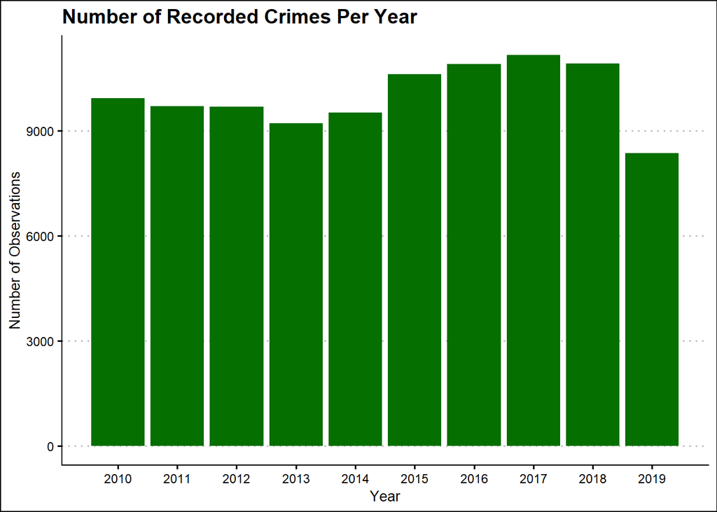

This graph contains all 100,000 entries and has no particular trend that would suggest crime has been steadily increasing or decreasing over time. I was, however, curious to know if, while there were no trends per year, if there was a trend in other measures of time.

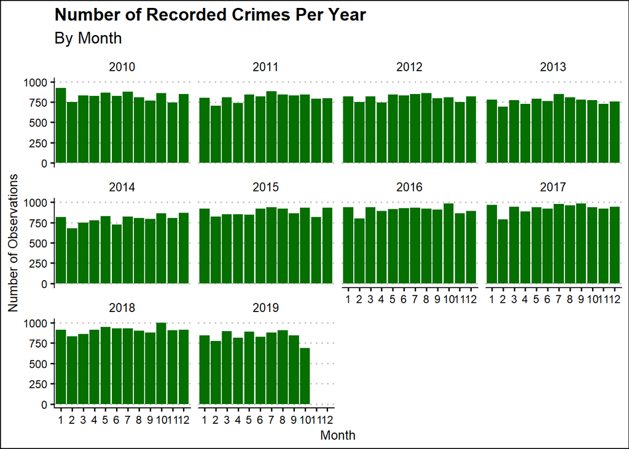

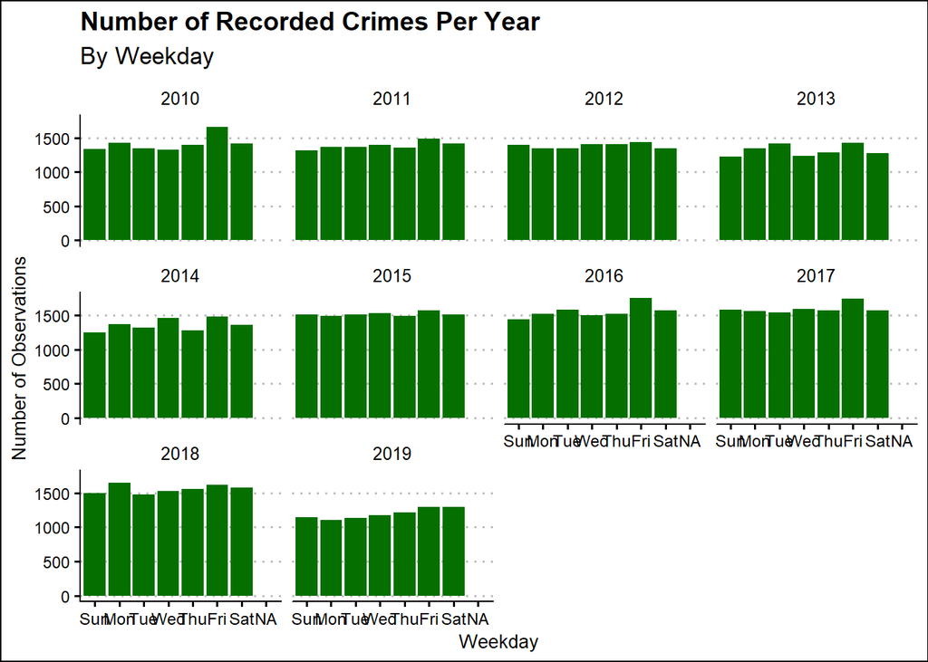

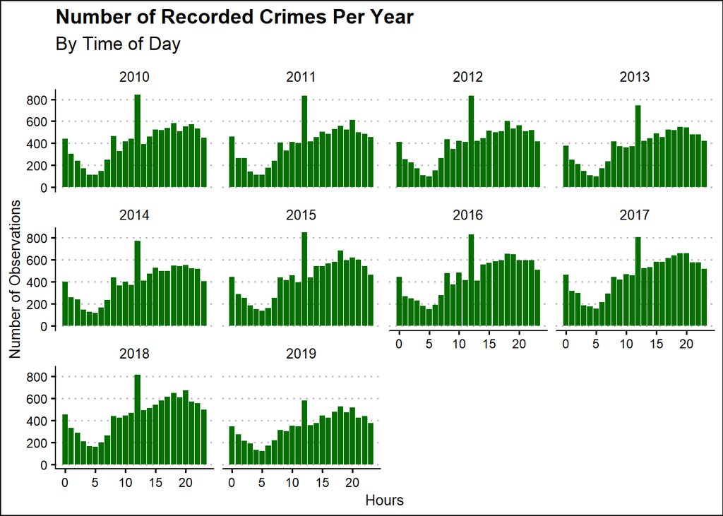

While these simple graphs answered my questions about the number of crimes over time, it raised more questions.

### Victims

When I first counted the number of victims, I noticed a few things.

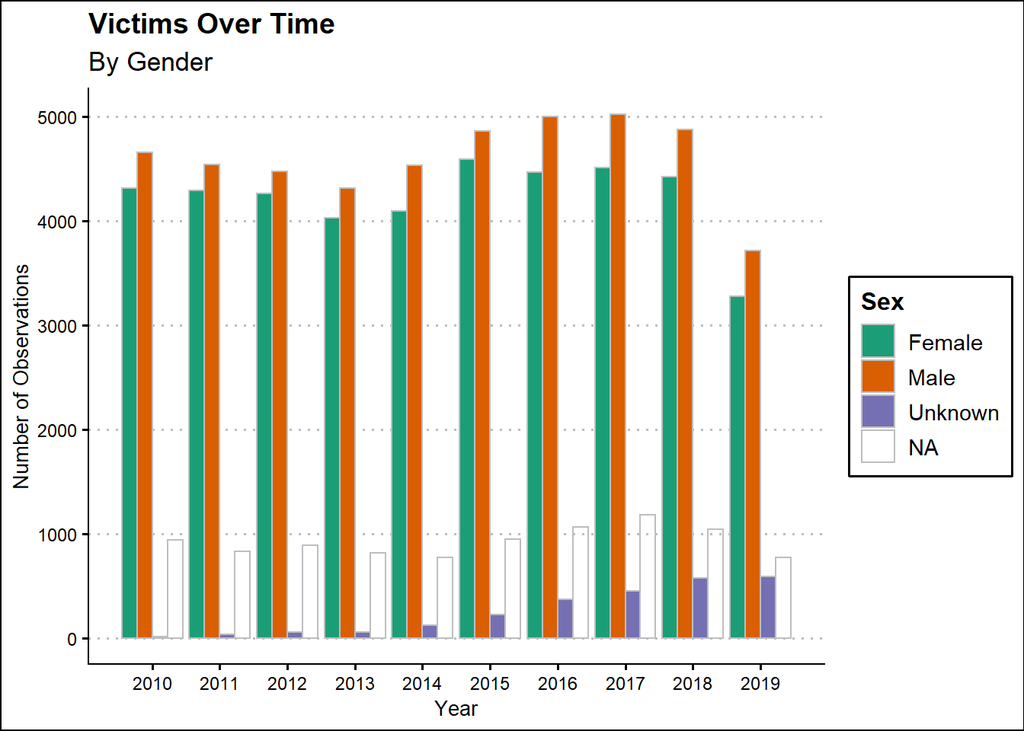

The number of male and female victims were very close. In fact, in my current sample they are 41,981 female entries and 46,225 male, a difference that, while more than four thousand is relatively close.

I also noticed the number of `NA` values, and the number of values that did not appear to be related. Since there were very few of them, I decided to relabel them as unknown sex. I could have set them to `NA` but I thought that the missing data here could relate to the type of crime or be significant in another way, so I decided to possibly corrupt the unknown category instead.

I moved on to look at the race of the victims. However, I wanted to see not only if there was trend over time between the race and ethnicity of the victim but what trends each group had for their respective genders.

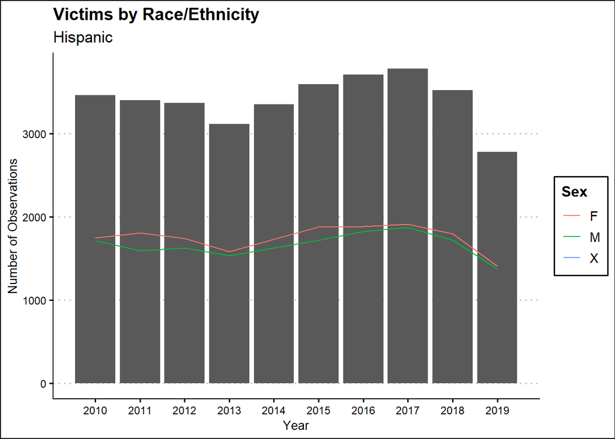

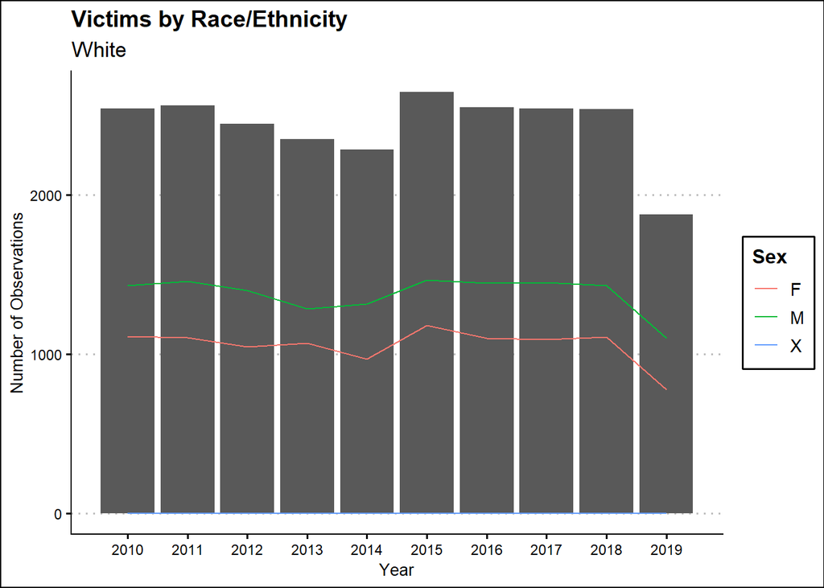

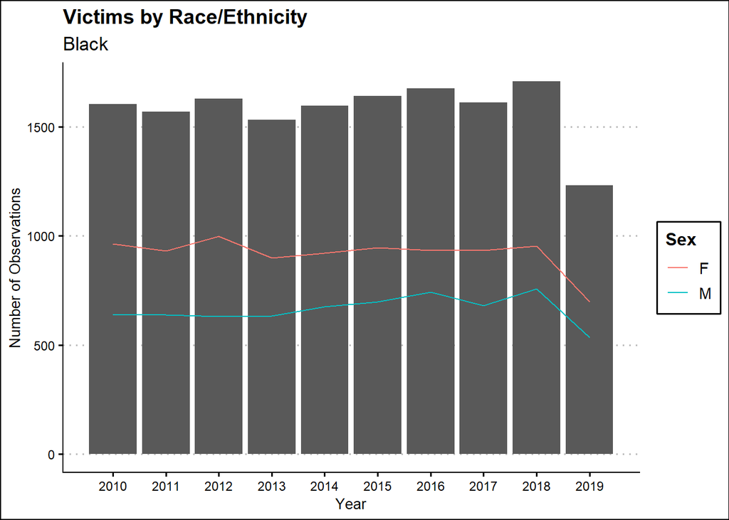

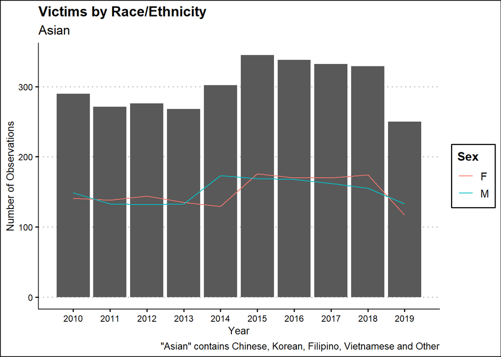

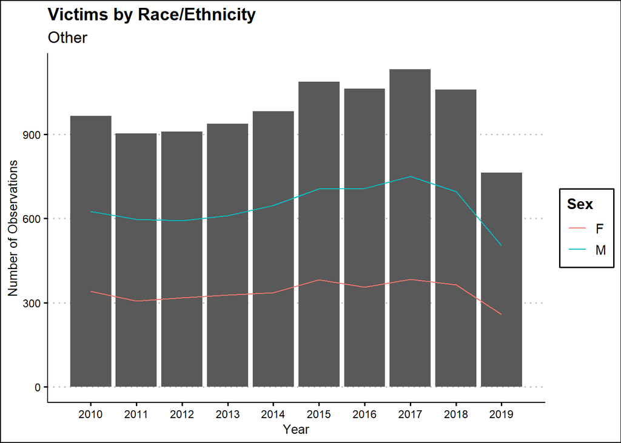

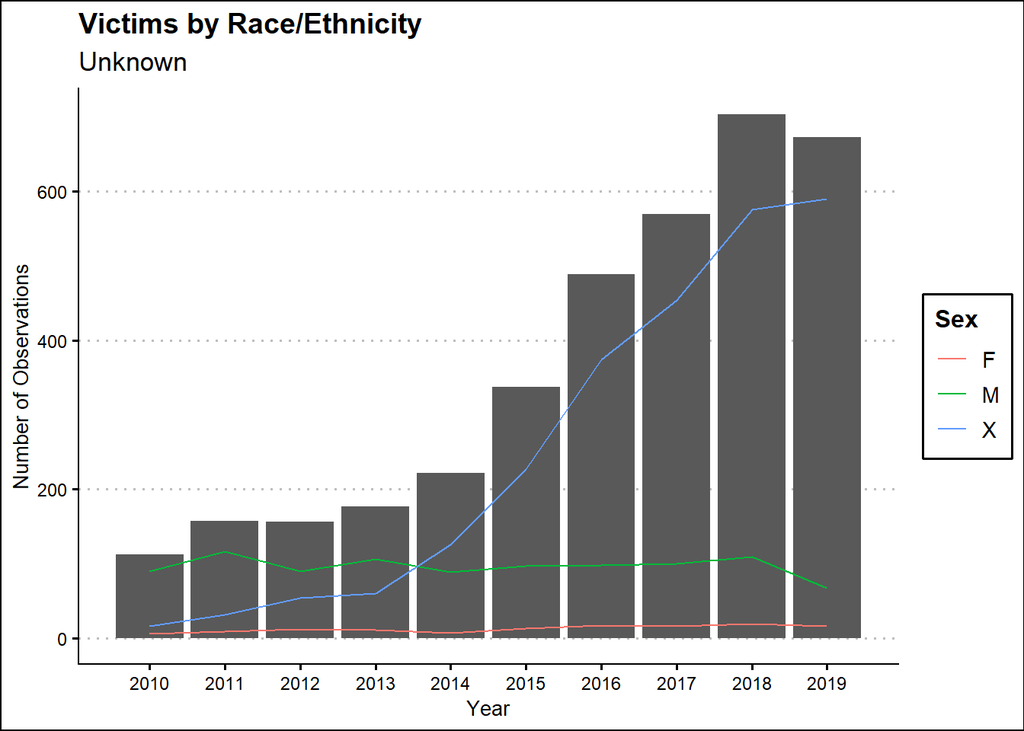

All of the different races have a similar trend between their sexes, but there are some interesting things to notice. First, there are more Hispanic, Black and sometimes Asian victims who are female than male in their respective category. Secondly, there is an upward trend of Victims of an Unknown race, whose gender is also unknown.

The number of crimes related to each race seem fairly even, although I would note that there are, in general more Hispanic, White and Black victims, with Asian coming in lowest.

When I went to consider age in relation to all this, I realized that instead of using `0` as an actual age, it was used as unknown. Since most of the `NA` values were related to `0`s I omitted them from my graphs below.

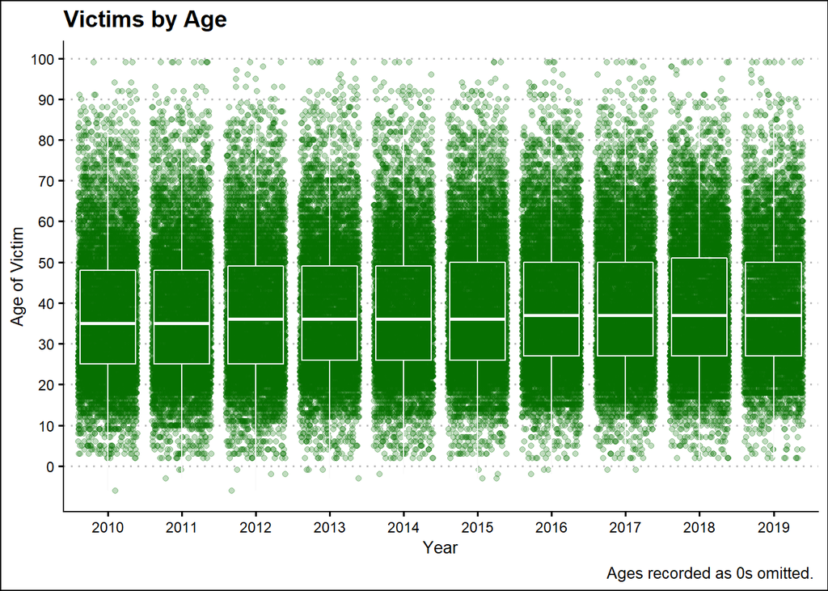

The simplest way to see the average age, seemed to be a box plot, given difficulties of over plotting, and binning the data by hand. The interesting thing to note here is that, although the data ranges high, low and the mean doesn’t change very much it always falls between 30 and 40.

This begs the question of if the average age changes in relation to gender or race.

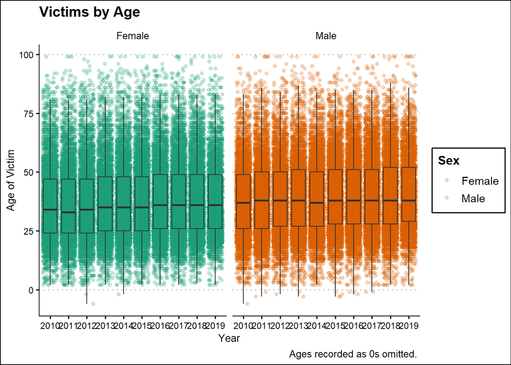

[output not shown]

It appears that male victims and female victims don’t vary much in age. Race was slightly more complicated, so I decided to compare it alongside sex.

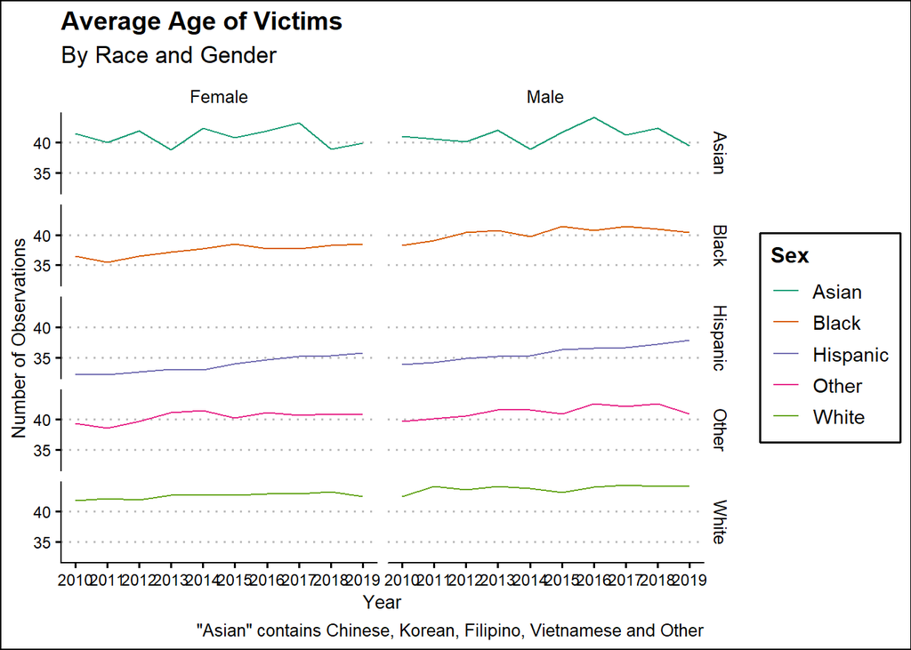

While I looked several different categories, the type of crime I spent the most time on was theft. Broken down into multiple categories, that contained everything from identity theft to shoplifting, to Bunco, I wanted to see how it changed over time and what those categories came down to.

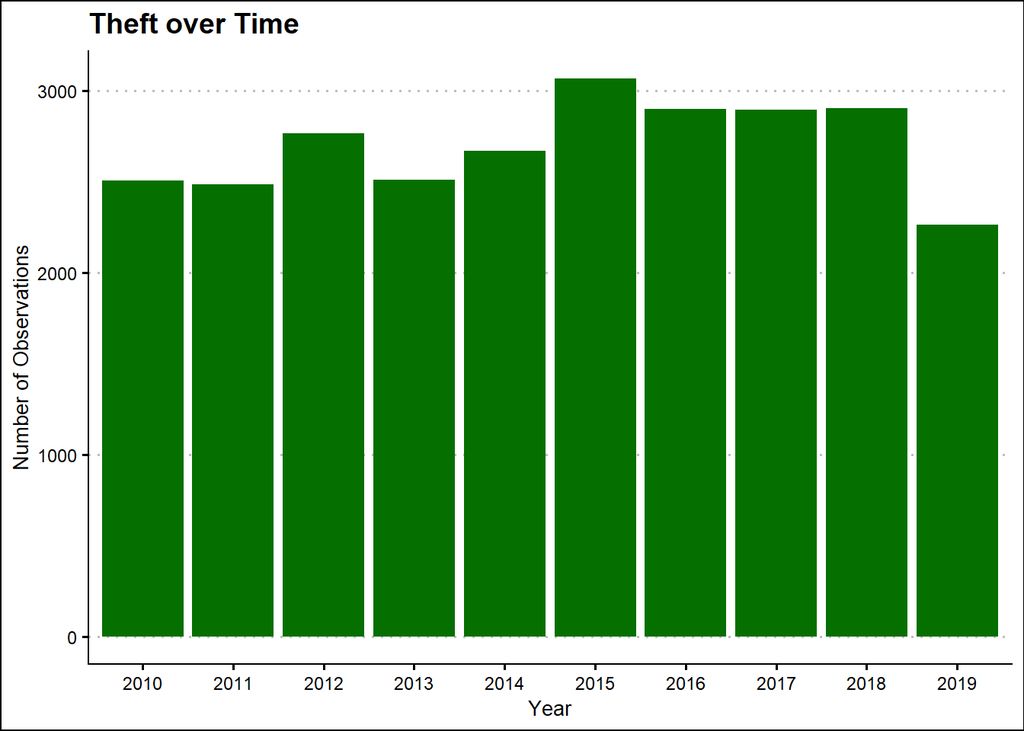

Like other variables we looked, theft remains fairly even over time. What we can see, is that petty theft has grown over the past 10 years, not necessarily in numbers, given that slight drop off above, but in percent.

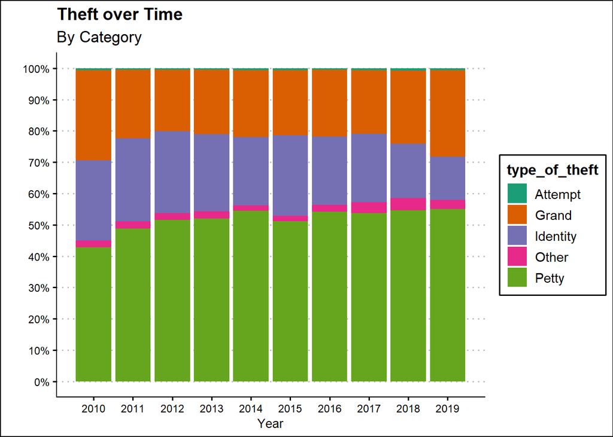

While I could have continued to look at the ways that crime varied in description over time, I also decided to look at how weapons description varied over time. I was particularly interested here in guns, and the crimes they were used for.

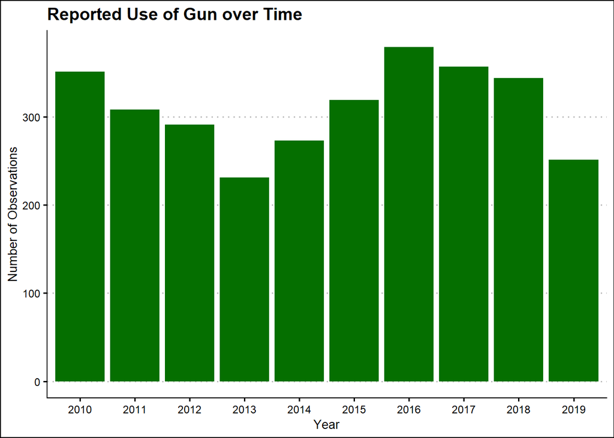

[figure not shown]

There is an interesting decrease in 2013 of gun use, which we saw back at the beginning as well. It would be interesting to consider if there were any new laws made, or laws that changed that would have affected the rate of crime in general or gun use. Another interesting fact is that no homicides made it past the filter of 15 or above.

### Location

My final point of interest was location data, but I was disappointed by the current attached geographic data. While I had originally thought the attached geographic data was related to the city as a whole, it was instead mostly related to the locations of police stations. Divided up into 21 reporting stations, instead of actual areas of the city, I decided to see if I could see any changes over time anyway.

[output not shown]

[output not shown]

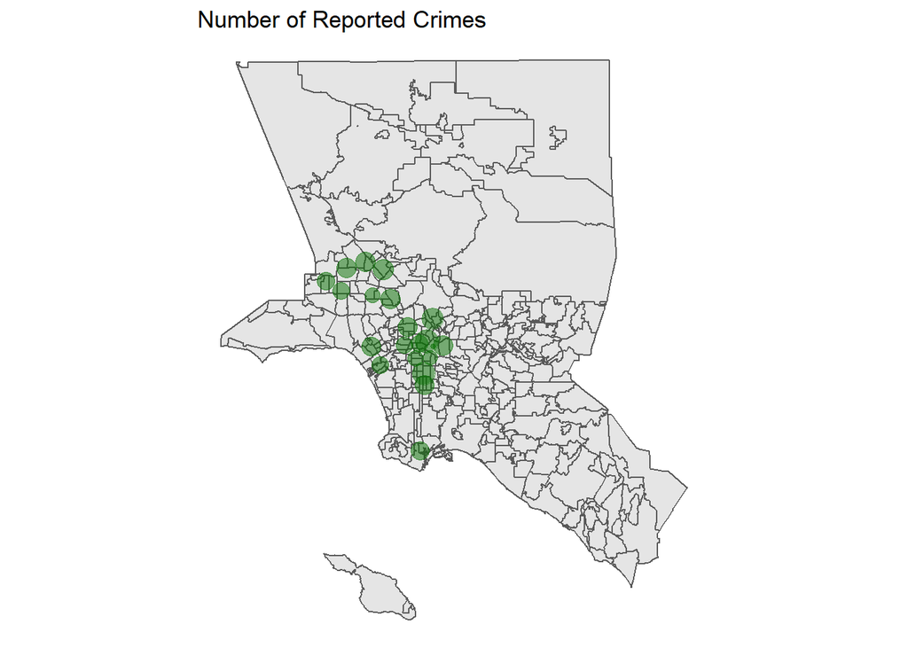

While it looks like there is potential to see changes over time, it is very difficult to see any trends when faceted by year. I think to make a better version of this I would need to figure out a way to turn it into a heat map.

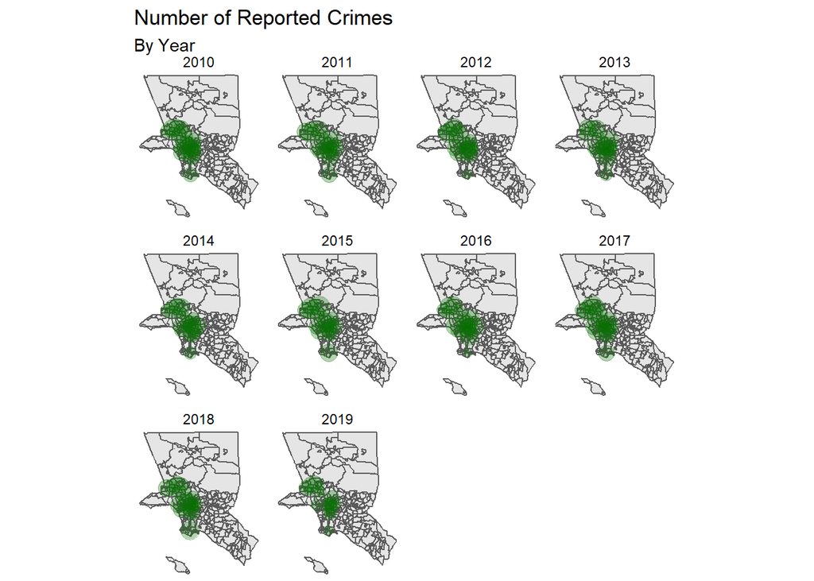

### Conclusion

After exploring the [LA Crime Data Set](https://data.lacity.org/A-Safe-City/Crime-Data-from-2010-to-Present/63jg-8b9z), which is publicly available at data.lacity.org, I have more questions than I have answers. I barely grazed the surface of what this data set could show me, as I followed the five paths I decided on.

If I were to continue this project, I would take a serious look at the interactions between victim type, weapon type, crime type and even time measures other than year. I would also probably want to consider the `NA` values, and their purpose.